# Tugas Praktikum 3.2

2025-09-18

##PACKAGES

```r
#install.packages("dLagM") a
#install.packages("dynlm")
#install.packages("MLmetrics")
library(dLagM)
library(dynlm)
library(MLmetrics)
library(lmtest)
library(car)
```

## DATA

```r
# Langkah 1: Baca / Buat Data
library(tibble)
 data_aqi <- tribble(
   ~AQI, ~SO2,
   30.2, 0.3874302,
   28.2, 0.40978193,
   26.6, 0.40233135,
   25, 0.37625432,
   26, 0.33900142,
   26, 0.31292439,
   26, 0.31292439,
   24, 0.3427267,
   23, 0.39488077,
   24, 0.42840838,
   25, 0.42840838,
   26, 0.39860606,
   27, 0.3501773,
   29, 0.31664968,
   29, 0.29802322,
   29, 0.28684735,
   29, 0.28312206,
   28, 0.29429793,
   27, 0.3017485,
   27, 0.3054738,
   27, 0.3091991,
   27, 0.31292439,
   27, 0.32037497,
   27, 0.32410026,
   27, 0.32782555,
   28, 0.32782555,
   29, 0.32037497,
   31, 0.31664968,
   31, 0.31292439,
   32, 0.31664968,
   32, 0.31664968,
   31, 0.31664968,
   31, 0.32037497,
   30, 0.32037497,
   30, 0.32410026,
   29, 0.32782555,
   27, 0.33900142,
   26, 0.3501773,
   25, 0.35762787,
   25, 0.36507845,
   24, 0.37252903,
   24, 0.37625432,
   25, 0.37625432,
   25, 0.37252903,
   25, 0.37252903,
   26, 0.37252903,
   26, 0.3799796,
   27, 0.39115548,
   27, 0.39860606,
   27, 0.39860606,
   27, 0.3874302,
   28, 0.37625432,
   28, 0.36507845,
   27, 0.36880374,
   27, 0.37625432,
   26, 0.3837049,
   25, 0.40233135,
   23, 0.42840838,
   22, 0.44330955,
   21, 0.45448542,
   20, 0.45448542,
   19, 0.45076013,
   19, 0.43958426,
   20, 0.4209578,
   21, 0.40978193,
   21, 0.40605664,
   21, 0.39860606,
   22, 0.39115548,
   24, 0.3837049,
   26, 0.37625432,
   27, 0.37252903,
   28, 0.36880374
 )
# Cek data
 head(data_aqi)
```

```
## # A tibble: 6 × 2
##     AQI   SO2
##   <dbl> <dbl>
## 1  30.2 0.387
## 2  28.2 0.410
## 3  26.6 0.402
## 4  25   0.376
## 5  26   0.339
## 6  26   0.313
```

## PEMBAGIAN DATA

```r
# Langkah 2: Split Data (Training & Testing)
# 28 baris data → 80% (≈22) buat training, sisanya (6) buat testing
train <- data_aqi[1:22, ]   # 22 baris pertama untuk training
test  <- data_aqi[23:28, ]  # 6 baris terakhir untuk testing

# Cek hasil split
nrow(train)
```

```
## [1] 22
```

```r
nrow(test)
```

```
## [1] 6
```

```r
# Langkah 3: Buat Data Time Series
# Asumsinya data berurutan (baris = waktu)
train.ts <- ts(train)
test.ts  <- ts(test)
data.ts  <- ts(data_aqi)
```

```r
# Cek time series train
 train.ts
```

```
## Time Series:
## Start = 1
## End = 22
## Frequency = 1
##     AQI       SO2
##  1 30.2 0.3874302
##  2 28.2 0.4097819
##  3 26.6 0.4023313
##  4 25.0 0.3762543
##  5 26.0 0.3390014
##  6 26.0 0.3129244
##  7 26.0 0.3129244
##  8 24.0 0.3427267
##  9 23.0 0.3948808
## 10 24.0 0.4284084
## 11 25.0 0.4284084
## 12 26.0 0.3986061
## 13 27.0 0.3501773
## 14 29.0 0.3166497
## 15 29.0 0.2980232
## 16 29.0 0.2868474
## 17 29.0 0.2831221
## 18 28.0 0.2942979
## 19 27.0 0.3017485
## 20 27.0 0.3054738
## 21 27.0 0.3091991
## 22 27.0 0.3129244
```

```r
# Langkah 4: Model Koyck
 library(dLagM)
# Bangun model Koyck: AQI (Y) ~ SO2 (X)
 model.koyck <- koyckDlm(x = train$SO2, y = train$AQI)
# Lihat hasil model
 summary(model.koyck)
```

```
##
## Call:
## "Y ~ (Intercept) + Y.1 + X.t"
##
## Residuals:
##     Min      1Q  Median      3Q     Max
## -2.0416 -0.5450  0.2028  0.7038  2.2050
##
## Coefficients:
##             Estimate Std. Error t value Pr(>|t|)
## (Intercept)   6.7602     5.7952   1.167  0.25863
## Y.1           0.7456     0.1527   4.882  0.00012 ***
## X.t          -0.3004     6.7894  -0.044  0.96520
## ---
## Signif. codes:  0 '***' 0.001 '**' 0.01 '*' 0.05 '.' 0.1 ' ' 1
##
## Residual standard error: 1.05 on 18 degrees of freedom
## Multiple R-Squared: 0.677,   Adjusted R-squared: 0.6412
## Wald test: 18.78 on 2 and 18 DF,  p-value: 3.926e-05
##
## Diagnostic tests:
## NULL
##
##                             alpha       beta       phi
## Geometric coefficients:  26.56805 -0.3003793 0.7455527
```

```r
 # Lihat AIC & BIC untuk mengecek kebaikan model
AIC(model.koyck)
```

```
## [1] 66.39031
```

```r
BIC(model.koyck)
```

```
## [1] 70.5684
```

Dari hasil tersebut, didapat bahwa peubah $Y_{t-1}$ memiliki nilai P-Value < 0.05, sedangkan peubah $X_t$ memiliki nilai P-Value > 0.05. Hal ini menunjukkan bahwa hanya peubah $Y_{t-1}$ yang berpengaruh signifikan terhadap $Y$ (AQI), sedangkan peubah $X_t$ (SO2) tidak berpengaruh signifikan.

Adapun model keseluruhannya adalah sebagai berikut:

$${Y}_t = 6.7602 - 0.3004X_t +
0.7456Y_{t-1}$$

### Peramalan dan Akurasi

```r
## Langkah 5: Peramalan dan Akurasi Model Koyck
# Peramalan 5 periode ke depan menggunakan model Koyck
 fore.koyck <- forecast(model = model.koyck, x = test$SO2, h = 5)

# Tampilkan hasil peramalan
fore.koyck
```

```
## $forecasts
## [1] 26.79386 26.63905 26.52251 26.43562 26.37309
##
## $call
## forecast.koyckDlm(model = model.koyck, x = test$SO2, h = 5)
##
## attr(,"class")
## [1] "forecast.koyckDlm" "dLagM"
```

```r
# Langkah 6: Menghitung MAPE Model Koyck (dengan penyesuaian panjang data)
mape.koyck <- MAPE(fore.koyck$forecasts, test$AQI[1:5])
mape.koyck
```

```
## [1] 0.03702843
```

```r
# Langkah 7: Akurasi Data Training
 GoF(model.koyck)
```

```
##              n       MAE          MPE       MAPE      sMAPE     MASE       MSE
## model.koyck 21 0.7629349 -0.001388049 0.02901807 0.02886038 1.003862 0.9442294
##                   MRAE   GMRAE
## model.koyck 1413290258 4370.87
```

## Regression with Distributed Lag

### Pemodelan (Lag=2)

```r
# Langkah 8: Regression with Distributed Lag (Lag = 2)
# Bangun model DLM dengan lag = 2
model.dlm <- dlm(x = train$SO2, y = train$AQI, q = 2)

# Lihat hasil model
summary(model.dlm)
```

```
##
## Call:
## lm(formula = model.formula, data = design)
##
## Residuals:
##     Min      1Q  Median      3Q     Max
## -1.3508 -0.6755 -0.1901  0.7274  1.8083
##
## Coefficients:
##             Estimate Std. Error t value Pr(>|t|)
## (Intercept)    37.89       2.55  14.857 8.82e-11 ***
## x.t           -80.85      20.37  -3.970   0.0011 **
## x.1            80.12      33.05   2.424   0.0276 *
## x.2           -33.00      19.36  -1.704   0.1077
## ---
## Signif. codes:  0 '***' 0.001 '**' 0.01 '*' 0.05 '.' 0.1 ' ' 1
##
## Residual standard error: 1.014 on 16 degrees of freedom
## Multiple R-squared:  0.7202, Adjusted R-squared:  0.6677
## F-statistic: 13.73 on 3 and 16 DF,  p-value: 0.0001088
##
## AIC and BIC values for the model:
##        AIC      BIC
## 1 62.83444 67.81311
```

```r
# Langkah 9: Mengecek AIC dan BIC Model DLM
AIC(model.dlm)
```

```
## [1] 62.83444
```

```r
BIC(model.dlm)
```

```
## [1] 67.81311
```

### Peramalan dan Akurasi

```r
# Langkah 10: Peramalan 5 Periode ke Depan dengan Model DLM
# Peramalan Y (AQI) untuk 5 periode ke depan
fore.dlm <- forecast(model = model.dlm, x = test$SO2, h = 5)

# Tampilkan hasil peramalan
fore.dlm
```

```
## $forecasts
## [1] 26.85615 27.02895 26.78037 26.95590 27.43535
##
## $call
## forecast.dlm(model = model.dlm, x = test$SO2, h = 5)
##
## attr(,"class")
## [1] "forecast.dlm" "dLagM"
```

```r
# Langkah 11: Menghitung MAPE Model DLM
mape.dlm <- MAPE(fore.dlm$forecasts, test$AQI[1:5])
mape.dlm
```

```
## [1] 0.02115547
```

```r
# Langkah 12: Akurasi Data Training untuk Model DLM
GoF(model.dlm)
```

```
##            n       MAE          MPE       MAPE      sMAPE     MASE      MSE
## model.dlm 20 0.7823253 -0.001112294 0.02915466 0.02916623 1.092954 0.821885
##                 MRAE    GMRAE
## model.dlm 3302508822 8899.333
```

### Lag Optimum

```r
# Langkah 13: Penentuan Lag Optimum
train.df <- as.data.frame(train)
str(train.df)
```

```
## 'data.frame':    22 obs. of  2 variables:
##  $ AQI: num  30.2 28.2 26.6 25 26 26 26 24 23 24 ...
##  $ SO2: num  0.387 0.41 0.402 0.376 0.339 ...
```

```r
 # FiniteDLMauto
finiteDLMauto(
   formula = AQI ~ SO2,
   data = train.df,
   q.min = 1,
   q.max = 10,
   model.type = "dlm",
   error.type = "AIC",
   trace = TRUE
 )
```

```
##    q - k    MASE      AIC      BIC       GMRAE    MBRAE R.Adj.Sq   Ljung-Box
## 10    10 0.00000     -Inf     -Inf     0.00003  0.27273      NaN         NaN
## 9      9 0.17686  5.85737 12.63676  7121.67075  0.48750  0.96268 0.284502714
## 8      8 0.54191 35.88795 42.91758  9522.64073  0.26986  0.84692 0.312650945
## 7      7 0.69969 43.66089 50.74139  5992.86307 -0.08238  0.81936 0.755931965
## 6      6 0.65648 46.37646 53.32976  2906.31637  0.00449  0.81333 0.590412327
## 5      5 0.78417 51.82899 58.49469  7445.24099  0.33817  0.76551 0.310205623
## 4      4 0.96323 56.65090 62.88350 18589.44947  0.17641  0.71635 0.071770723
## 3      3 1.04620 59.68345 65.35008 11679.09917  0.20966  0.70047 0.022471410
## 2      2 1.09295 62.83444 67.81311  8899.33326  0.60667  0.66770 0.018380808
## 1      1 1.27589 77.28753 81.46562  4627.02992  0.40787  0.39708 0.007226377
```

### Pemodelan

```r
# Langkah 14: Model DLM dengan lag optimum (q = 6)
# Membuat vektor untuk input dan output
x_train <- train$SO2  # variabel input
y_train <- train$AQI  # variabel output

 # Membuat model DLM dengan lag optimum
 model.dlm2 <- dlm(x = x_train, y = y_train, q = 6)

 # Melihat ringkasan model
 summary(model.dlm2)
```

```
##
## Call:
## lm(formula = model.formula, data = design)
##
## Residuals:
##      Min       1Q   Median       3Q      Max
## -0.95228 -0.34279 -0.06934  0.47593  1.15895
##
## Coefficients:
##             Estimate Std. Error t value Pr(>|t|)
## (Intercept)   34.952      3.306  10.573 5.59e-06 ***
## x.t          -98.545     26.744  -3.685  0.00618 **
## x.1           95.851     66.881   1.433  0.18971
## x.2          -18.792     87.179  -0.216  0.83472
## x.3           -3.426     88.508  -0.039  0.97007
## x.4          -33.718     84.278  -0.400  0.69956
## x.5           45.909     66.680   0.688  0.51061
## x.6          -12.243     29.758  -0.411  0.69157
## ---
## Signif. codes:  0 '***' 0.001 '**' 0.01 '*' 0.05 '.' 0.1 ' ' 1
##
## Residual standard error: 0.8306 on 8 degrees of freedom
## Multiple R-squared:  0.9004, Adjusted R-squared:  0.8133
## F-statistic: 10.34 on 7 and 8 DF,  p-value: 0.001874
##
## AIC and BIC values for the model:
##        AIC      BIC
## 1 46.37646 53.32976
```

```r
# Langkah 15: Menghitung AIC dan BIC model DLM
AIC(model.dlm2)
```

```
## [1] 46.37646
```

```r
BIC(model.dlm2)
```

```
## [1] 53.32976
```

$$\hat{Y}_t = 34.952 - 98.545 X_t + 95.851 X_{t-1} - 18.792 X_{t-2} -
3.426 X_{t-3} - 33.718 X_{t-4} + 45.909 X_{t-5} - 12.243 X_{t-6}$$

Dimana $\hat{Y}_t$ adalah nilai prediksi AQI pada waktu $t$ dan $X_t$ adalah variabel SO2 pada waktu $t$.

### Peramalan dan Akurasi

```r
# Langkah 16 : Peramalan 5 periode ke depan menggunakan model DLM
fore.dlm2 <- forecast(model = model.dlm2, x=test$SO2, h=5)

# Ambil nilai aktual dari data test (AQI)
 y_true <- tail(test$AQI, 5)

 # Hitung MAPE
 mape.dlm2 <- MAPE(fore.dlm2$forecasts, y_true)
 mape.dlm2
```

```
## [1] 0.05617019
```

```r
# Langkah 16 : # Akurasi data training
 GoF(model.dlm2)
```

```
##             n       MAE           MPE       MAPE      sMAPE      MASE       MSE
## model.dlm2 16 0.4814169 -0.0004574599 0.01805573 0.01805132 0.6564775 0.3449527
##                  MRAE    GMRAE
## model.dlm2 1156629807 2906.316
```

## Pemodelan DLM & ARDL dengan Library dynlm

```r
# Langkah 17: Pemodelan Autoregressive Distributed Lag (ARDL)
 library(dLagM)

 # Membuat model ARDL dengan lag 1 untuk Y (AQI) dan lag 1 untuk X (SO2)
 model.ardl <- ardlDlm(x = train$SO2, y = train$AQI, p = 1, q = 1)

 # Melihat ringkasan model ARDL
 summary(model.ardl)
```

```
##
## Time series regression with "ts" data:
## Start = 2, End = 22
##
## Call:
## dynlm(formula = as.formula(model.text), data = data, start = 1)
##
## Residuals:
##     Min      1Q  Median      3Q     Max
## -1.7957 -0.3162  0.1693  0.3569  1.4265
##
## Coefficients:
##             Estimate Std. Error t value Pr(>|t|)
## (Intercept)  11.4566     4.0496   2.829  0.01158 *
## X.t         -27.7805     7.8146  -3.555  0.00244 **
## X.1          21.7484     7.4798   2.908  0.00980 **
## Y.1           0.6407     0.1127   5.687 2.67e-05 ***
## ---
## Signif. codes:  0 '***' 0.001 '**' 0.01 '*' 0.05 '.' 0.1 ' ' 1
##
## Residual standard error: 0.8217 on 17 degrees of freedom
## Multiple R-squared:  0.813,  Adjusted R-squared:   0.78
## F-statistic: 24.64 on 3 and 17 DF,  p-value: 2.022e-06
```

```r
# Langkah 18: Menghitung AIC dan BIC untuk model ARDL
 AIC(model.ardl)
```

```
## [1] 56.91123
```

```r
 BIC(model.ardl)
```

```
## [1] 62.13385
```

# Kesimpulan Model Regresi Deret Waktu

Berdasarkan hasil regresi deret waktu, model menunjukkan bahwa peubah $X_{t}$, lag dari peubah $X$ yaitu $X_{t-1}$, dan lag dari peubah $Y$ yaitu $Y_{t-1}$ berpengaruh signifikan terhadap $Y_t$ dengan nilai p < 0,05. Hal ini menandakan bahwa baik nilai saat ini maupun lag dari peubah $X$ dan lag dari peubah $Y$ berperan dalam memengaruhi $Y_t$.

Persamaan modelnya adalah sebagai berikut:

$$\hat{Y}_t = 11.4566 - 27.7805 X_t + 21.7484 X_{t-1} + 0.6407 Y_{t-1}$$

Nilai AIC sebesar 56.91 dan BIC sebesar 62.13 menunjukkan model ini memiliki keseimbangan yang baik antara kesesuaian dan kompleksitas.

Koefisien determinasi $R^2 = 0.813$ dan adjusted $R^2 = 0.78$ menandakan bahwa model mampu menjelaskan sekitar 78–81% variasi data. Residual standard error sebesar 0.8217 mengindikasikan kesalahan prediksi relatif kecil.

Secara keseluruhan, model ini dapat dianggap cukup baik dan signifikan secara statistik (F-statistic = 24.64; p-value = 2.022e-06).

```r
 #Langkah 19: Peramalan dan Akurasi Model ARDL

 # Koefisien ARDL
 b0 <- 11.4566
 b1 <- -27.7805
 b2 <- 21.7484
 b3 <- 0.6407

 # Data test
 x_t <- test$SO2
 y_t1 <- c(tail(train$AQI,1), head(test$AQI,-1))  # lag Y
 x_t1 <- c(tail(train$SO2,1), head(test$SO2,-1))  # lag X

 # Forecast 5 periode ke depan
 fore.ardl <- b0 + b1*x_t + b2*x_t1 + b3*y_t1

 # Tampilkan hasil forecast
 fore.ardl
```

```
## [1] 26.66093 26.71948 26.69700 26.77802 27.62570 28.20786
```

```r
# Nilai aktual dari test set
 y_true <- test$AQI
```

```r
# Langkah 19: Akurasi Model ARDL
# Nilai aktual dari test set
 y_true <- test$AQI

 # Hitung MAPE manual
 mape.ardl <- mean(abs((y_true - fore.ardl)/y_true)) * 100
 mape.ardl
```

```
## [1] 3.587846
```

```r
# Langkah 20 : akurasi data training
 GoF(model.ardl)
```

```
##             n      MAE           MPE       MAPE      sMAPE      MASE      MSE
## model.ardl 21 0.562972 -0.0007579776 0.02161339 0.02153002 0.7407526 0.546616
##                  MRAE   GMRAE
## model.ardl 1497056284 3268.62
```

```r
library(dLagM)

 # Penentuan lag optimum berdasarkan AIC
 model.ardl.opt <- ardlBoundOrders(
   data = data.frame(data_aqi),  # dataset
   ic = "AIC",                   # kriteria informasi
   formula = AQI ~ SO2           # formula Y ~ X
 )

 # Tampilkan hasil lag optimum
  model.ardl.opt
```

```
## $p
##   SO2
## 1   5
##
## $q
## [1] 14
##
## $Stat.table
##           q = 1    q = 2    q = 3    q = 4    q = 5    q = 6    q = 7    q = 8
## p = 1  165.0404 157.0835 154.3424 149.0481 148.7001 144.5253 143.2922 143.6106
## p = 2  164.9284 158.5905 153.8422 146.6973 145.4782 138.4297 137.2184 137.7014
## p = 3  156.4618 156.4618 155.8202 147.4034 145.0694 138.0337 137.6525 137.3678
## p = 4  150.4278 152.3936 152.3936 149.3628 146.6416 139.0573 139.0670 138.4002
## p = 5  135.6917 137.6305 138.9924 138.9924 133.9385 129.4598 130.9483 130.5605
## p = 6  122.5407 124.2793 126.1956 128.1817 128.1817 130.1785 131.2474 130.7990
## p = 7  128.3135 130.1790 131.0634 130.2348 127.9205 127.9205 129.9204 130.9908
## p = 8  134.1794 136.1761 136.3410 133.8000 129.1847 131.1621 131.1621 132.9660
## p = 9  118.8344 120.6104 120.9542 121.8102 119.7311 120.0859 121.9468 121.9468
## p = 10 120.5894 119.2576 117.3998 116.0302 116.8429 116.3463 116.2849 117.7454
## p = 11 130.8815 126.9603 123.3923 119.8382 120.0437 119.2123 118.5586 119.6773
## p = 12 132.3671 127.8043 124.3325 121.9028 121.7754 117.9769 118.3657 118.5884
## p = 13 130.6334 127.6459 122.9865 119.8019 120.4849 116.6321 118.3894 117.7972
## p = 14 130.5242 127.8724 123.2364 118.9536 116.7495 111.9228 113.5861 112.1408
## p = 15 126.2306 126.9956 124.8533 119.3648 117.9591 114.1426 116.1418 115.4277
##           q = 9   q = 10   q = 11   q = 12   q = 13   q = 14   q = 15
## p = 1  142.5334 142.0414 140.2427 138.6383 137.0140 134.9935 134.9125
## p = 2  134.9813 136.0189 132.9201 128.5933 127.9145 128.9478 130.2901
## p = 3  134.7977 135.2543 132.6501 126.6164 125.9899 126.5780 127.0482
## p = 4  135.9886 136.3469 134.5831 128.5439 127.9119 128.1734 128.7442
## p = 5  123.2464 121.8505 119.1522 118.0084 114.8815 107.6614 108.9574
## p = 6  124.3647 123.7250 121.1324 120.0045 116.8685 109.6030 110.7021
## p = 7  122.7261 122.1274 119.7607 119.9151 117.6097 111.0412 111.7987
## p = 8  124.6470 124.0525 121.5518 120.8627 115.1859 109.2013 110.1115
## p = 9  123.9130 124.2478 122.7870 122.5341 117.0139 110.8243 111.6109
## p = 10 117.7454 119.7453 120.9848 122.0215 116.4983 112.1325 113.3027
## p = 11 121.5678 121.5678 122.9840 124.0104 118.4049 114.1212 115.1376
## p = 12 120.0579 121.6839 121.6839 123.0578 110.6238 110.2178 111.8593
## p = 13 119.6904 121.6615 122.1964 122.1964 111.2389 108.7065 109.3147
## p = 14 113.8831 115.7760 110.9634 109.3423 109.3423 110.5354 111.2475
## p = 15 117.4276 119.3269 116.2629 116.3765 111.4490 111.4490 113.2307
##
## $min.Stat
## [1] 107.6614
```

```r
# Inisialisasi vektor untuk menyimpan nilai minimum AIC tiap q
 min_p <- c()

# Hitung minimum AIC tiap q (lag Y)
 for(i in 1:length(model.ardl.opt$Stat.table)) {
   min_p[i] <- min(model.ardl.opt$Stat.table[[i]], na.rm = TRUE)
 }

 # Tentukan q optimum (lag Y)
 q_opt <- which(min_p == min(min_p, na.rm = TRUE))

 # Tentukan p optimum (lag X) untuk q optimum
 p_opt <- which(model.ardl.opt$Stat.table[[q_opt]] ==
                min(model.ardl.opt$Stat.table[[q_opt]], na.rm = TRUE))

 # Buat data.frame ringkas hasil
 data.frame(
   "q_optimum" = q_opt,
   "p_optimum" = p_opt,
   "AIC" = model.ardl.opt$min.Stat
 )
```

```
##   q_optimum p_optimum      AIC
## 1        14         5 107.6614
```

```r
# Langkah 22: Menampilkan ringkasan model linear
 library(dynlm)

 # DLM q=1
 cons_lm1 <- dynlm(AQI ~ SO2 + L(SO2), data = train.ts)

 # ARDL p=1 q=0
 cons_lm2 <- dynlm(AQI ~ SO2 + L(AQI), data = train.ts)

 # ARDL p=1 q=1
 cons_lm3 <- dynlm(AQI ~ SO2 + L(SO2) + L(AQI), data = train.ts)

 # DLM p=2
 cons_lm4 <- dynlm(AQI ~ SO2 + L(SO2) + L(SO2, 2), data = train.ts)

 # Ringkasan model DLM & ARDL
 summary(cons_lm1)  # DLM q=1
```

```
##
## Time series regression with "ts" data:
## Start = 2, End = 22
##
## Call:
## dynlm(formula = AQI ~ SO2 + L(SO2), data = train.ts)
##
## Residuals:
##     Min      1Q  Median      3Q     Max
## -1.9440 -1.1226 -0.1197  1.0603  3.4056
##
## Coefficients:
##             Estimate Std. Error t value Pr(>|t|)
## (Intercept)   33.188      2.219  14.955 1.36e-11 ***
## SO2          -39.547     12.476  -3.170   0.0053 **
## L(SO2)        20.163     12.375   1.629   0.1206
## ---
## Signif. codes:  0 '***' 0.001 '**' 0.01 '*' 0.05 '.' 0.1 ' ' 1
##
## Residual standard error: 1.36 on 18 degrees of freedom
## Multiple R-squared:  0.4574, Adjusted R-squared:  0.3971
## F-statistic: 7.586 on 2 and 18 DF,  p-value: 0.004079
```

### Ringkasan Model

```r
 summary(cons_lm2)  # ARDL p=1 q=0
```

```
##
## Time series regression with "ts" data:
## Start = 2, End = 22
##
## Call:
## dynlm(formula = AQI ~ SO2 + L(AQI), data = train.ts)
##
## Residuals:
##      Min       1Q   Median       3Q      Max
## -2.13389 -0.40191 -0.03036  0.52201  2.00314
##
## Coefficients:
##             Estimate Std. Error t value Pr(>|t|)
## (Intercept)  12.8763     4.7806   2.693 0.014857 *
## SO2          -8.9931     5.2266  -1.721 0.102460
## L(AQI)        0.6285     0.1339   4.694 0.000181 ***
## ---
## Signif. codes:  0 '***' 0.001 '**' 0.01 '*' 0.05 '.' 0.1 ' ' 1
##
## Residual standard error: 0.9772 on 18 degrees of freedom
## Multiple R-squared:  0.7201, Adjusted R-squared:  0.689
## F-statistic: 23.15 on 2 and 18 DF,  p-value: 1.056e-05
```

```r
 summary(cons_lm3)  # ARDL p=1 q=1
```

```
##
## Time series regression with "ts" data:
## Start = 2, End = 22
##
## Call:
## dynlm(formula = AQI ~ SO2 + L(SO2) + L(AQI), data = train.ts)
##
## Residuals:
##     Min      1Q  Median      3Q     Max
## -1.7957 -0.3162  0.1693  0.3569  1.4265
##
## Coefficients:
##             Estimate Std. Error t value Pr(>|t|)
## (Intercept)  11.4566     4.0496   2.829  0.01158 *
## SO2         -27.7805     7.8146  -3.555  0.00244 **
## L(SO2)       21.7484     7.4798   2.908  0.00980 **
## L(AQI)        0.6407     0.1127   5.687 2.67e-05 ***
## ---
## Signif. codes:  0 '***' 0.001 '**' 0.01 '*' 0.05 '.' 0.1 ' ' 1
##
## Residual standard error: 0.8217 on 17 degrees of freedom
## Multiple R-squared:  0.813,  Adjusted R-squared:   0.78
## F-statistic: 24.64 on 3 and 17 DF,  p-value: 2.022e-06
```

```r
 summary(cons_lm4)  # DLM p=2
```

```
##
## Time series regression with "ts" data:
## Start = 3, End = 22
##
## Call:
## dynlm(formula = AQI ~ SO2 + L(SO2) + L(SO2, 2), data = train.ts)
##
## Residuals:
##     Min      1Q  Median      3Q     Max
## -1.3508 -0.6755 -0.1901  0.7274  1.8083
##
## Coefficients:
##             Estimate Std. Error t value Pr(>|t|)
## (Intercept)    37.89       2.55  14.857 8.82e-11 ***
## SO2           -80.85      20.37  -3.970   0.0011 **
## L(SO2)         80.12      33.05   2.424   0.0276 *
## L(SO2, 2)     -33.00      19.36  -1.704   0.1077
## ---
## Signif. codes:  0 '***' 0.001 '**' 0.01 '*' 0.05 '.' 0.1 ' ' 1
##
## Residual standard error: 1.014 on 16 degrees of freedom
## Multiple R-squared:  0.7202, Adjusted R-squared:  0.6677
## F-statistic: 13.73 on 3 and 16 DF,  p-value: 0.0001088
```

```r
library(broom)

 model_list <- list(cons_lm1, cons_lm2, cons_lm3, cons_lm4)
 model_names <- c("DLM q=1", "ARDL p=1 q=0", "ARDL p=1 q=1", "DLM p=2")

 model_summary <- lapply(model_list, function(x) {
   tidy(x)  # Ambil koefisien
 })
```

```r
names(model_summary) <- model_names

 # Lihat ringkasan koefisien
 model_summary
```

```
## $`DLM q=1`
## # A tibble: 3 × 5
##   term        estimate std.error statistic  p.value
##   <chr>          <dbl>     <dbl>     <dbl>    <dbl>
## 1 (Intercept)     33.2      2.22     15.0  1.36e-11
## 2 SO2            -39.5     12.5      -3.17 5.30e- 3
## 3 L(SO2)          20.2     12.4       1.63 1.21e- 1
##
## $`ARDL p=1 q=0`
## # A tibble: 3 × 5
##   term        estimate std.error statistic  p.value
##   <chr>          <dbl>     <dbl>     <dbl>    <dbl>
## 1 (Intercept)   12.9       4.78       2.69 0.0149
## 2 SO2           -8.99      5.23      -1.72 0.102
## 3 L(AQI)         0.628     0.134      4.69 0.000181
##
## $`ARDL p=1 q=1`
## # A tibble: 4 × 5
##   term        estimate std.error statistic   p.value
##   <chr>          <dbl>     <dbl>     <dbl>     <dbl>
## 1 (Intercept)   11.5       4.05       2.83 0.0116
## 2 SO2          -27.8       7.81      -3.55 0.00244
## 3 L(SO2)        21.7       7.48       2.91 0.00980
## 4 L(AQI)         0.641     0.113      5.69 0.0000267
##
## $`DLM p=2`
## # A tibble: 4 × 5
##   term        estimate std.error statistic  p.value
##   <chr>          <dbl>     <dbl>     <dbl>    <dbl>
## 1 (Intercept)     37.9      2.55     14.9  8.82e-11
## 2 SO2            -80.8     20.4      -3.97 1.10e- 3
## 3 L(SO2)          80.1     33.0       2.42 2.76e- 2
## 4 L(SO2, 2)      -33.0     19.4      -1.70 1.08e- 1
```

### SSE

```r
# Menghitung SSE untuk masing-masing model
 sse_lm1 <- deviance(cons_lm1)  # DLM q=1
 sse_lm2 <- deviance(cons_lm2)  # ARDL p=1 q=0
 sse_lm3 <- deviance(cons_lm3)  # ARDL p=1 q=1
 sse_lm4 <- deviance(cons_lm4)  # DLM p=2

 # Menampilkan hasil
 sse_lm1
```

```
## [1] 33.31646
```

```r
 sse_lm2
```

```
## [1] 17.18753
```

```r
 sse_lm3
```

```
## [1] 11.47894
```

```r
 sse_lm4
```

```
## [1] 16.4377
```

### Ui encomptest

```r
 if(!require(lmtest)) install.packages("lmtest")
 library(lmtest)

 # Uji perbandingan model
 encomptest(cons_lm1, cons_lm2)
```

```
## Encompassing test
##
## Model 1: AQI ~ SO2 + L(SO2)
## Model 2: AQI ~ SO2 + L(AQI)
## Model E: AQI ~ SO2 + L(SO2) + L(AQI)
##           Res.Df Df       F    Pr(>F)
## M1 vs. ME     17 -1 32.3408 2.675e-05 ***
## M2 vs. ME     17 -1  8.4543  0.009803 **
## ---
## Signif. codes:  0 '***' 0.001 '**' 0.01 '*' 0.05 '.' 0.1 ' ' 1
```

Berdasarkan hasil encompassing test terhadap model DLM & ARDL:

- **Model 1 (AQI ~ SO2 + L(SO2))**  
  p-value = 2.675e-05 (< 0.01).  
  Artinya, penambahan lag dari Y (L(AQI)) memberikan peningkatan signifikan terhadap model. Dengan demikian, Model 1 **belum memadai** tanpa tambahan lag dari Yt.
- **Model 2 (AQI ~ SO2 + L(AQI))**  
  p-value = 0.009803 (< 0.01).  
  Artinya, penambahan lag dari X (L(SO2)) memberikan peningkatan signifikan. Sehingga Model 2 **tidak cukup memadai** tanpa tambahan lag dari Xt.
- **Model E (AQI ~ SO2 + L(SO2) + L(AQI))**  
  Merupakan model gabungan yang sudah mempertimbangkan lag dari kedua variabel, sehingga menjadi model yang lebih lengkap dan memadai untuk menjelaskan variabilitas AQI.

### Uji Autokorelasi Residual

```r
dwtest(cons_lm1)
```

```
##
##  Durbin-Watson test
##
## data:  cons_lm1
## DW = 0.55857, p-value = 9.92e-06
## alternative hypothesis: true autocorrelation is greater than 0
```

```r
dwtest(cons_lm2)
```

```
##
##  Durbin-Watson test
##
## data:  cons_lm2
## DW = 0.94967, p-value = 0.001153
## alternative hypothesis: true autocorrelation is greater than 0
```

```r
dwtest(cons_lm3)
```

```
##
##  Durbin-Watson test
##
## data:  cons_lm3
## DW = 1.2795, p-value = 0.009503
## alternative hypothesis: true autocorrelation is greater than 0
```

```r
dwtest(cons_lm4)
```

```
##
##  Durbin-Watson test
##
## data:  cons_lm4
## DW = 0.92883, p-value = 0.0007327
## alternative hypothesis: true autocorrelation is greater than 0
```

Berdasarkan hasil uji Durbin-Watson, semua model menunjukkan **autokorelasi positif** pada residualnya (DW < 2).  
- Model 1: DW = 0.55857, autokorelasi sangat kuat.  
- Model 2: DW = 0.94967, autokorelasi positif menurun.  
- Model 3: DW = 1.2795, autokorelasi positif berkurang, model ini paling mendekati independensi residual.  
- Model 4: DW = 0.92883, autokorelasi positif tetap ada.

**Kesimpulan:** Model 3 merupakan pilihan terbaik dari sisi autokorelasi residual.

### Uji Heterogenitas

```r
bptest(cons_lm1)
```

```
##
##  studentized Breusch-Pagan test
##
## data:  cons_lm1
## BP = 1.9113, df = 2, p-value = 0.3846
```

```r
bptest(cons_lm2)
```

```
##
##  studentized Breusch-Pagan test
##
## data:  cons_lm2
## BP = 1.1786, df = 2, p-value = 0.5547
```

```r
bptest(cons_lm3)
```

```
##
##  studentized Breusch-Pagan test
##
## data:  cons_lm3
## BP = 1.444, df = 3, p-value = 0.6953
```

```r
bptest(cons_lm4)
```

```
##
##  studentized Breusch-Pagan test
##
## data:  cons_lm4
## BP = 8.4529, df = 3, p-value = 0.03752
```

Berdasarkan hasil uji Breusch-Pagan:

- **Model 1:** BP = 1.9113, p-value = 0.3846 (> 0.05), tidak terdapat heteroskedastisitas.
- **Model 2:** BP = 1.1786, p-value = 0.5547 (> 0.05), tidak terdapat heteroskedastisitas.
- **Model 3:** BP = 1.444, p-value = 0.6953 (> 0.05), tidak terdapat heteroskedastisitas.
- **Model 4:** BP = 8.4529, p-value = 0.03752 (< 0.05), terdapat **heteroskedastisitas**, artinya variansi residual tidak konstan.

**Kesimpulan:** Model 1, 2, dan 3 bebas dari heteroskedastisitas, sedangkan Model 4 perlu diperbaiki atau di-transformasi untuk mengatasi masalah variansi residual yang tidak konstan.

### Uji Normalitas

```r
shapiro.test(residuals(cons_lm1))
```

```
##
##  Shapiro-Wilk normality test
##
## data:  residuals(cons_lm1)
## W = 0.93137, p-value = 0.1467
```

```r
shapiro.test(residuals(cons_lm2))
```

```
##
##  Shapiro-Wilk normality test
##
## data:  residuals(cons_lm2)
## W = 0.97527, p-value = 0.8444
```

```r
shapiro.test(residuals(cons_lm3))
```

```
##
##  Shapiro-Wilk normality test
##
## data:  residuals(cons_lm3)
## W = 0.96792, p-value = 0.6868
```

```r
shapiro.test(residuals(cons_lm4))
```

```
##
##  Shapiro-Wilk normality test
##
## data:  residuals(cons_lm4)
## W = 0.96289, p-value = 0.6031
```

Berdasarkan hasil uji Shapiro-Wilk terhadap residual:

- **Model 1:** W = 0.93137, p-value = 0.1467 (> 0.05), residual berdistribusi normal.
- **Model 2:** W = 0.97527, p-value = 0.8444 (> 0.05), residual berdistribusi normal.
- **Model 3:** W = 0.96792, p-value = 0.6868 (> 0.05), residual berdistribusi normal.
- **Model 4:** W = 0.96289, p-value = 0.6031 (> 0.05), residual berdistribusi normal.

**Kesimpulan:** Semua model memiliki residual yang berdistribusi normal, sehingga asumsi normalitas terpenuhi.

## Perbandingan Model

```r
# Perbandingan Model berdasarkan MAPE
 akurasi <- matrix(c(mape.koyck, mape.dlm, mape.dlm2, mape.ardl))
 row.names(akurasi) <- c("Koyck", "DLM 1", "DLM 2", "Autoregressive")
 colnames(akurasi) <- c("MAPE")
 akurasi
```

```
##                      MAPE
## Koyck          0.03702843
## DLM 1          0.02115547
## DLM 2          0.05617019
## Autoregressive 3.58784563
```

**Kesimpulan:** Model dengan nilai MAPE terendah menunjukkan akurasi prediksi terbaik. Dari hasil ini, dapat dilihat model yang paling sesuai untuk data AQI dan SO2 adalah model yang memiliki MAPE terkecil.

## PLOT

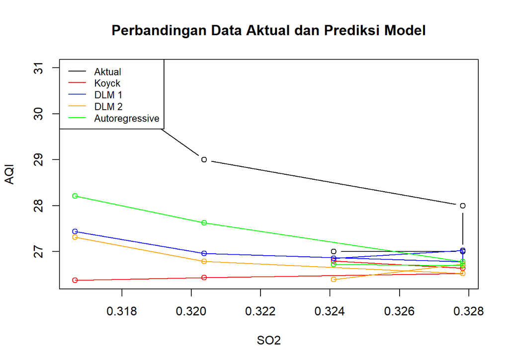

```r
# Ambil 5 periode terakhir dari data aktual
x_plot <- tail(test$SO2, 5)
y_actual <- tail(test$AQI, 5)

# Ambil 5 periode terakhir dari masing-masing forecast
koyck_fore <- tail(as.numeric(fore.koyck$forecasts), 5)
dlm1_fore  <- tail(as.numeric(fore.dlm$forecasts), 5)
dlm2_fore  <- tail(as.numeric(fore.dlm2$forecasts), 5)
ardl_fore  <- tail(as.numeric(fore.ardl), 5)

# Plot
plot(x_plot, y_actual, type="b", col="black",
     ylim=range(c(y_actual, koyck_fore, dlm1_fore, dlm2_fore, ardl_fore)),
     xlab="SO2", ylab="AQI", main="Perbandingan Data Aktual dan Prediksi Model")

points(x_plot, koyck_fore, col="red");   lines(x_plot, koyck_fore, col="red")
points(x_plot, dlm1_fore, col="blue");   lines(x_plot, dlm1_fore, col="blue")
points(x_plot, dlm2_fore, col="orange"); lines(x_plot, dlm2_fore, col="orange")
points(x_plot, ardl_fore, col="green");  lines(x_plot, ardl_fore, col="green")

legend("topleft",
       legend=c("Aktual", "Koyck","DLM 1","DLM 2", "Autoregressive"),
       lty=1, col=c("black","red","blue","orange","green"), cex=0.8)
```

## Kesimpulan Akhir: Perbandingan Model

Dari grafik perbandingan antara data aktual (AQI) dan prediksi model:

**Kesimpulan:** Model **DLM 1** adalah model terbaik untuk memprediksi AQI berdasarkan SO2 pada dataset ini. Model lain dapat digunakan sebagai alternatif, namun akurasi dan kesesuaian model lebih rendah.